# RT-qPCR 2026-02-11 on SUN4-mNG 5’ UTR mutant strains

Benny Kleinerman & Edward Wallace

11/02/2026

# Experimental Design

Replicates:

- 3 biological replicates (from different colonies) are collected for each strain
- 3 technical replicates +RT and 1 -RT

Test Primers:

- mNG_1
- SUN4_1

Reference gene primers:

- ACT1_1
- PGK1_2
- SRO9_1
- SSD1_1

```r
library(tidyqpcr)
library(forcats)
```

```r
library(ggplot2)
library(dplyr)
library(tidyr)
library(readr)
library(ggbeeswarm)
```

# Describe the experimental design in a plate plan

## Columns are target_ids of primer sets

```r
colkey <- create_colkey_6_in_24(
  target_id = c("mNG_1", "SUN4_1", "ACT1_1", "PGK1_2", "SRO9_1", "SSD1_1") %>%
    as_factor()
)

print(colkey)
```

```
## # A tibble: 24 × 4
##    well_col prep_type tech_rep target_id
##    <fct>    <fct>     <fct>    <fct>
##  1 1        +RT       1        mNG_1
##  2 2        +RT       1        SUN4_1
##  3 3        +RT       1        ACT1_1
##  4 4        +RT       1        PGK1_2
##  5 5        +RT       1        SRO9_1
##  6 6        +RT       1        SSD1_1
##  7 7        +RT       2        mNG_1
##  8 8        +RT       2        SUN4_1
##  9 9        +RT       2        ACT1_1
## 10 10       +RT       2        PGK1_2
## # ℹ 14 more rows
```

## Rows are sample name, Strain, BioRep (3) and TechRep (3)

# Also choose colours to display strains.

```r
strain_df <- tibble(
  Strain = c(
    "yBK023",
    "yBK054",
    "yBK026",
    "yBK056",
    "yBK014",
    "yBK017",
    "yBK020",
    "yBK032",
    "yBK055",
    "yBK033",
    "yBK057",
    "yBK029",
    "yBK030",
    "yBK031"),
  fiveprimeUTR = rep(c(
      "xintless",
      "mutSBM1x",
      "mutSBM12x",
      "mutSBM12altx",
      "delSBM1x",
      "delSBM12x",
      "delSBMregx"),
    times = 2),
  background = c(rep("Wild Type", 7), rep("ssd1delta", 7)),
  colour = rgb(runif(14), runif(14), runif(14)))

scale_color_strain <-
  scale_color_manual("Strain",
                     breaks = strain_df$Strain,
                     values = strain_df$colour)

rowkey <- tibble(well_row = c(rep(LETTERS[1:16], 2), LETTERS[1:10]),
                 Strain = strain_df$Strain %>%
                   rep(each = 3) %>%
                   as_factor(),
                 fiveprimeUTR = strain_df$fiveprimeUTR %>%
                   rep(each = 3) %>%
                   as_factor(),
                 background = strain_df$background %>%
                   rep(each = 3) %>%
                   as_factor(),
                 BioRep = 1:3 %>%
                   as_factor() %>%
                   rep(times = 14)) %>%
  unite(sample_id, Strain, BioRep, remove = FALSE) %>%
  mutate(sample_id = as_factor(sample_id))

print(rowkey)
```

```
## # A tibble: 42 × 6
##    well_row sample_id Strain fiveprimeUTR background BioRep
##    <chr>    <fct>     <fct>  <fct>        <fct>      <fct>
##  1 A        yBK023_1  yBK023 xintless     Wild Type  1
##  2 B        yBK023_2  yBK023 xintless     Wild Type  2
##  3 C        yBK023_3  yBK023 xintless     Wild Type  3
##  4 D        yBK054_1  yBK054 mutSBM1x     Wild Type  1
##  5 E        yBK054_2  yBK054 mutSBM1x     Wild Type  2
##  6 F        yBK054_3  yBK054 mutSBM1x     Wild Type  3
##  7 G        yBK026_1  yBK026 mutSBM12x    Wild Type  1
##  8 H        yBK026_2  yBK026 mutSBM12x    Wild Type  2
##  9 I        yBK026_3  yBK026 mutSBM12x    Wild Type  3
## 10 J        yBK056_1  yBK056 mutSBM12altx Wild Type  1
## # ℹ 32 more rows
```

## Combine into plate plan

```r
plate_plan_1 <- label_plate_rowcol(
  plate = create_blank_plate(well_row = LETTERS[1:16], well_col = 1:24),
  rowkey = rowkey %>%
  dplyr::slice(1:16),
  colkey = colkey
)
```

```
## coercing well_row to a factor with levels from plate$well_row
```

```r
print(plate_plan_1)
```

```
## # A tibble: 384 × 11
##    well  well_row well_col prep_type tech_rep target_id sample_id Strain
##    <chr> <fct>    <fct>    <fct>     <fct>    <fct>     <fct>     <fct>
##  1 A1    A        1        +RT       1        mNG_1     yBK023_1  yBK023
##  2 A2    A        2        +RT       1        SUN4_1    yBK023_1  yBK023
##  3 A3    A        3        +RT       1        ACT1_1    yBK023_1  yBK023
##  4 A4    A        4        +RT       1        PGK1_2    yBK023_1  yBK023
##  5 A5    A        5        +RT       1        SRO9_1    yBK023_1  yBK023
##  6 A6    A        6        +RT       1        SSD1_1    yBK023_1  yBK023
##  7 A7    A        7        +RT       2        mNG_1     yBK023_1  yBK023
##  8 A8    A        8        +RT       2        SUN4_1    yBK023_1  yBK023
##  9 A9    A        9        +RT       2        ACT1_1    yBK023_1  yBK023
## 10 A10   A        10       +RT       2        PGK1_2    yBK023_1  yBK023
## # ℹ 374 more rows
## # ℹ 3 more variables: fiveprimeUTR <fct>, background <fct>, BioRep <fct>
```

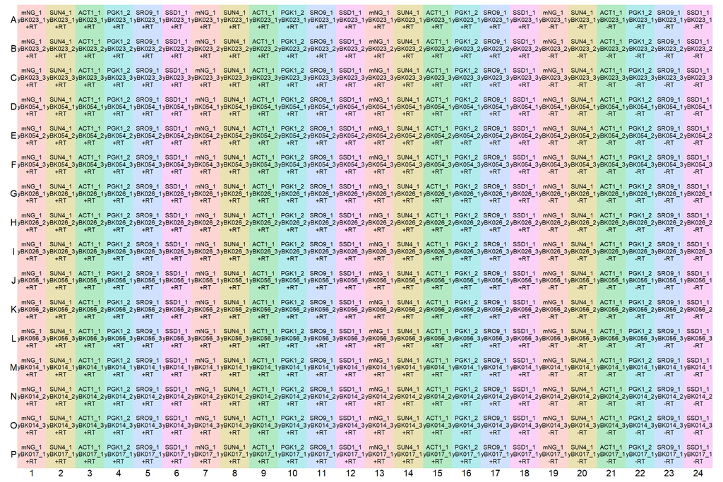

```r
display_plate_qpcr(plate_plan_1)
```

```r
plate_plan_2 <- label_plate_rowcol(
  plate = create_blank_plate(well_row = LETTERS[1:16], well_col = 1:24),
  rowkey = rowkey %>%
  dplyr::slice(17:32),
  colkey = colkey
)
```

```
## coercing well_row to a factor with levels from plate$well_row
```

```r
print(plate_plan_2)
```

```
## # A tibble: 384 × 11
##    well  well_row well_col prep_type tech_rep target_id sample_id Strain
##    <chr> <fct>    <fct>    <fct>     <fct>    <fct>     <fct>     <fct>
##  1 A1    A        1        +RT       1        mNG_1     yBK017_2  yBK017
##  2 A2    A        2        +RT       1        SUN4_1    yBK017_2  yBK017
##  3 A3    A        3        +RT       1        ACT1_1    yBK017_2  yBK017
##  4 A4    A        4        +RT       1        PGK1_2    yBK017_2  yBK017
##  5 A5    A        5        +RT       1        SRO9_1    yBK017_2  yBK017
##  6 A6    A        6        +RT       1        SSD1_1    yBK017_2  yBK017
##  7 A7    A        7        +RT       2        mNG_1     yBK017_2  yBK017
##  8 A8    A        8        +RT       2        SUN4_1    yBK017_2  yBK017
##  9 A9    A        9        +RT       2        ACT1_1    yBK017_2  yBK017
## 10 A10   A        10       +RT       2        PGK1_2    yBK017_2  yBK017
## # ℹ 374 more rows
## # ℹ 3 more variables: fiveprimeUTR <fct>, background <fct>, BioRep <fct>
```

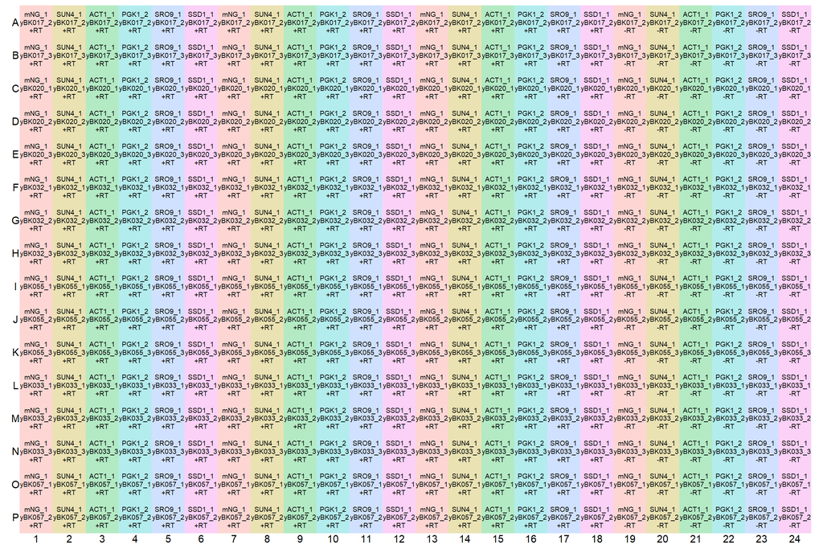

```r
display_plate_qpcr(plate_plan_2)
```

```r
plate_plan_3 <- label_plate_rowcol(
  plate = create_blank_plate(well_row = LETTERS[1:10], well_col = 1:24),
  rowkey = rowkey %>%
  dplyr::slice(33:42),
  colkey = colkey
)
```

```
## coercing well_row to a factor with levels from plate$well_row
```

```r
print(plate_plan_3)
```

```
## # A tibble: 240 × 11
##    well  well_row well_col prep_type tech_rep target_id sample_id Strain
##    <chr> <fct>    <fct>    <fct>     <fct>    <fct>     <fct>     <fct>
##  1 A1    A        1        +RT       1        mNG_1     yBK057_3  yBK057
##  2 A2    A        2        +RT       1        SUN4_1    yBK057_3  yBK057
##  3 A3    A        3        +RT       1        ACT1_1    yBK057_3  yBK057
##  4 A4    A        4        +RT       1        PGK1_2    yBK057_3  yBK057
##  5 A5    A        5        +RT       1        SRO9_1    yBK057_3  yBK057
##  6 A6    A        6        +RT       1        SSD1_1    yBK057_3  yBK057
##  7 A7    A        7        +RT       2        mNG_1     yBK057_3  yBK057
##  8 A8    A        8        +RT       2        SUN4_1    yBK057_3  yBK057
##  9 A9    A        9        +RT       2        ACT1_1    yBK057_3  yBK057
## 10 A10   A        10       +RT       2        PGK1_2    yBK057_3  yBK057
## # ℹ 230 more rows
## # ℹ 3 more variables: fiveprimeUTR <fct>, background <fct>, BioRep <fct>
```

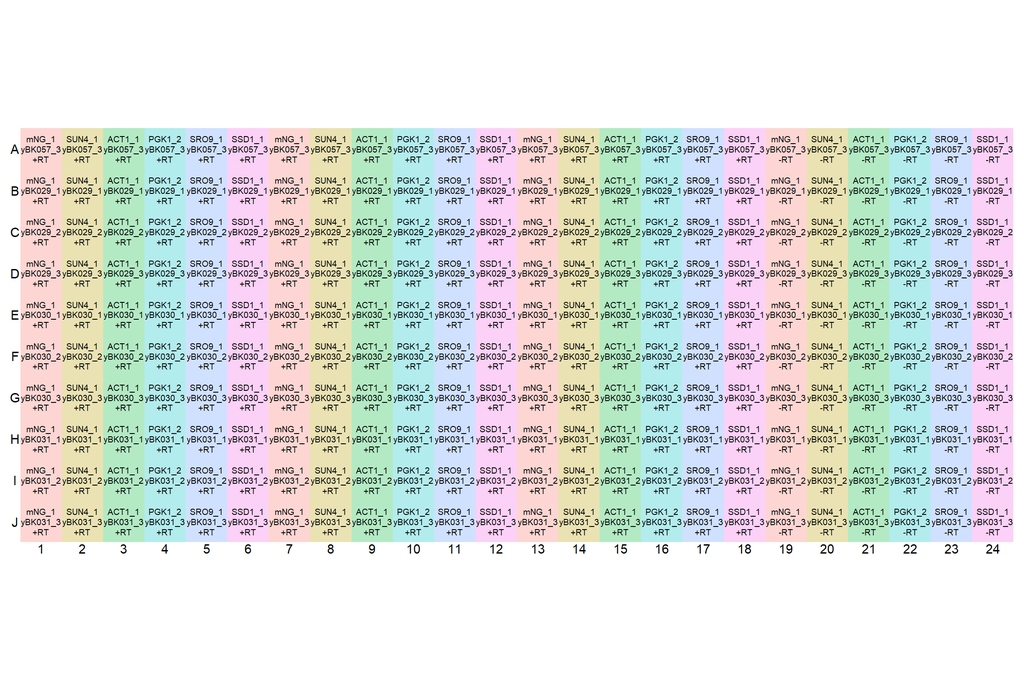

```r
display_plate_qpcr(plate_plan_3)
```

```r
plate_1 <- here::here("2026-02-11_SUN4mut_RTqPCR_ct/2026-02-11_SUN4-mNG_RTqPCR_ADH1only_p1_BK_ct.txt") %>%
  read_tsv(skip=1) %>%
    mutate(well=Pos,cq=Cp, plate_id = "1") %>%
    right_join(plate_plan_1)
plate_2 <- here::here("2026-02-11_SUN4mut_RTqPCR_ct/2026-02-11_SUN4-mNG_RTqPCR_ADH1only_p2_BK_ct.txt") %>%
  read_tsv(skip=1) %>%
    mutate(well=Pos,cq=Cp, plate_id = "2") %>%
    right_join(plate_plan_2)
plate_3 <- here::here("2026-02-11_SUN4mut_RTqPCR_ct/2026-02-11_SUN4-mNG_RTqPCR_ADH1only_p3_BK_ct.txt") %>%
  read_tsv(skip=1) %>%
    mutate(well=Pos,cq=Cp, plate_id = "3") %>%
    right_join(plate_plan_3)
plates <- bind_rows(plate_1, plate_2, plate_3)
plates
```

```
## # A tibble: 1,008 × 21
##    Include Color Pos   Name         Cp Concentration Standard Status well     cq
##    <lgl>   <dbl> <chr> <chr>     <dbl> <lgl>            <dbl> <lgl>  <chr> <dbl>
##  1 TRUE      255 A1    Sample 1   15.6 NA                   0 NA     A1     15.6
##  2 TRUE      255 A2    Sample 2   17.4 NA                   0 NA     A2     17.4
##  3 TRUE      255 A3    Sample 3   14.5 NA                   0 NA     A3     14.5
##  4 TRUE      255 A4    Sample 4   12.8 NA                   0 NA     A4     12.8
##  5 TRUE      255 A5    Sample 5   17.7 NA                   0 NA     A5     17.7
##  6 TRUE      255 A6    Sample 6   16.5 NA                   0 NA     A6     16.5
##  7 TRUE      255 A7    Sample 7   16.8 NA                   0 NA     A7     16.8
##  8 TRUE      255 A8    Sample 8   18.9 NA                   0 NA     A8     18.9
##  9 TRUE      255 A9    Sample 9   14.1 NA                   0 NA     A9     14.1
## 10 TRUE      255 A10   Sample 10  12.8 NA                   0 NA     A10    12.8
## # ℹ 998 more rows
## # ℹ 11 more variables: plate_id <chr>, well_row <fct>, well_col <fct>,
## #   prep_type <fct>, tech_rep <fct>, target_id <fct>, sample_id <fct>,
## #   Strain <fct>, fiveprimeUTR <fct>, background <fct>, BioRep <fct>
```

# Plot all replicates, unnormalized

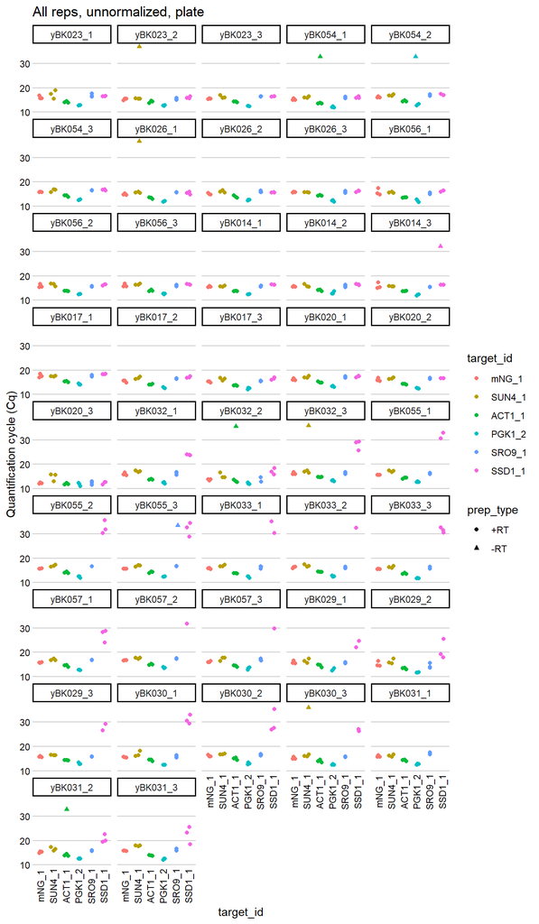

```r
ggplot(data = plates) +
  geom_point(aes(x = target_id, y = cq, shape = prep_type, colour = target_id),
    position = position_jitter(width = 0.2, height = 0)
  ) +
  labs(
    y = "Quantification cycle (Cq)",
    title = "All reps, unnormalized, plate"
  ) +
  facet_wrap(~sample_id, ncol = 5) +
  theme_classic() +
  theme(panel.grid.major.y = element_line(colour= "grey80"),
        panel.grid.minor = element_blank(),
        axis.line = element_blank(),
        axis.ticks = element_blank(),
        axis.text.x = element_text(angle = 90, vjust = 0.5))
```

The high or absent Cq values in -RT reactions indicate absence of DNA contamination.

# Check reference genes have consistent Cq across samples

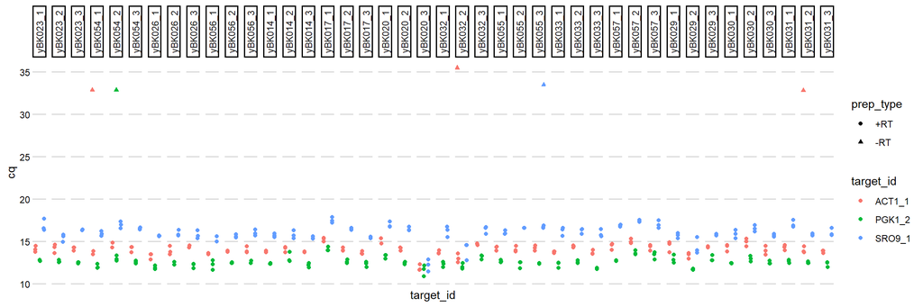

```r
ggplot(data = dplyr::filter(plates, target_id %in% c("ACT1_1", "PGK1_2", "SRO9_1") )) +
  geom_point(aes(x = target_id, y = cq, shape = prep_type, colour = target_id),
    position = position_jitter(width = 0.2, height = 0)) +
  facet_grid(~sample_id) +
  theme_classic() +
  theme(panel.grid.major.y = element_line(colour= "grey80"),
        panel.grid.minor = element_blank(),
        axis.line = element_blank(),
        axis.ticks = element_blank(),
        axis.text.x = element_blank(),
        strip.text.x = element_text(angle = 90, vjust = 0.5))
```

Cq values for reference genes are fairly consistent across samples, except for yBK020.3, and yBK032.2

# Normalise data by calculating ∆Cq against median of 3 reference genes

```r
plate_norm <- plates %>%
  dplyr::filter(prep_type == "+RT") %>%
  droplevels() %>%
  calculate_deltacq_bysampleid(ref_target_ids = c("ACT1_1", "PGK1_2", "SRO9_1"))

plate_norm
```

```
## # A tibble: 756 × 24
##    Include Color Pos   Name         Cp Concentration Standard Status well     cq
##    <lgl>   <dbl> <chr> <chr>     <dbl> <lgl>            <dbl> <lgl>  <chr> <dbl>
##  1 TRUE      255 A1    Sample 1   15.6 NA                   0 NA     A1     15.6
##  2 TRUE      255 A2    Sample 2   17.4 NA                   0 NA     A2     17.4
##  3 TRUE      255 A3    Sample 3   14.5 NA                   0 NA     A3     14.5
##  4 TRUE      255 A4    Sample 4   12.8 NA                   0 NA     A4     12.8
##  5 TRUE      255 A5    Sample 5   17.7 NA                   0 NA     A5     17.7
##  6 TRUE      255 A6    Sample 6   16.5 NA                   0 NA     A6     16.5
##  7 TRUE      255 A7    Sample 7   16.8 NA                   0 NA     A7     16.8
##  8 TRUE      255 A8    Sample 8   18.9 NA                   0 NA     A8     18.9
##  9 TRUE      255 A9    Sample 9   14.1 NA                   0 NA     A9     14.1
## 10 TRUE      255 A10   Sample 10  12.8 NA                   0 NA     A10    12.8
## # ℹ 746 more rows
## # ℹ 14 more variables: plate_id <chr>, well_row <fct>, well_col <fct>,
## #   prep_type <fct>, tech_rep <fct>, target_id <fct>, sample_id <fct>,
## #   Strain <fct>, fiveprimeUTR <fct>, background <fct>, BioRep <fct>,
## #   ref_cq <dbl>, delta_cq <dbl>, rel_abund <dbl>
```

```r
plate_norm_med <- plate_norm %>%
  group_by(sample_id, Strain, fiveprimeUTR, background, BioRep, target_id) %>%
  summarize(
    delta_cq = median(delta_cq, na.rm = TRUE),
    rel_abund = median(rel_abund, na.rm = TRUE)
  )
```

[output not shown]

```r
plate_norm_med
```

```
## # A tibble: 252 × 8
## # Groups:   sample_id, Strain, fiveprimeUTR, background, BioRep [42]
##    sample_id Strain fiveprimeUTR background BioRep target_id delta_cq rel_abund
##    <fct>     <fct>  <fct>        <fct>      <fct>  <fct>        <dbl>     <dbl>
##  1 yBK023_1  yBK023 xintless     Wild Type  1      mNG_1         1.55    0.342
##  2 yBK023_1  yBK023 xintless     Wild Type  1      SUN4_1        3.33    0.0994
##  3 yBK023_1  yBK023 xintless     Wild Type  1      ACT1_1        0       1
##  4 yBK023_1  yBK023 xintless     Wild Type  1      PGK1_2       -1.29    2.45
##  5 yBK023_1  yBK023 xintless     Wild Type  1      SRO9_1        2.51    0.176
##  6 yBK023_1  yBK023 xintless     Wild Type  1      SSD1_1        2.42    0.187
##  7 yBK023_2  yBK023 xintless     Wild Type  2      mNG_1         1.14    0.454
##  8 yBK023_2  yBK023 xintless     Wild Type  2      SUN4_1        1.15    0.451
##  9 yBK023_2  yBK023 xintless     Wild Type  2      ACT1_1        0       1
## 10 yBK023_2  yBK023 xintless     Wild Type  2      PGK1_2       -1.72    3.29
## # ℹ 242 more rows
```

# Plot ∆Cq for normalized data

For all replicates of all genes, all samples.

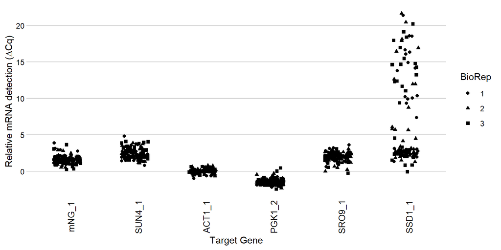

```r
ggplot(data = plate_norm) +
  geom_point(aes(x = target_id, y = delta_cq, shape = BioRep),
    position = position_jitter(width = 0.2, height = 0)
  ) +
  labs(x = "Target Gene",
         y = "Relative mRNA detection (∆Cq)") +
  theme_classic() +
  theme(panel.grid.major.y = element_line(colour= "grey80"),
        panel.grid.minor = element_blank(),
        axis.line = element_blank(),
        axis.ticks = element_blank(),
        axis.text.x = element_text(size = 10, angle = 90))
```